# 2.exploration (exercises)

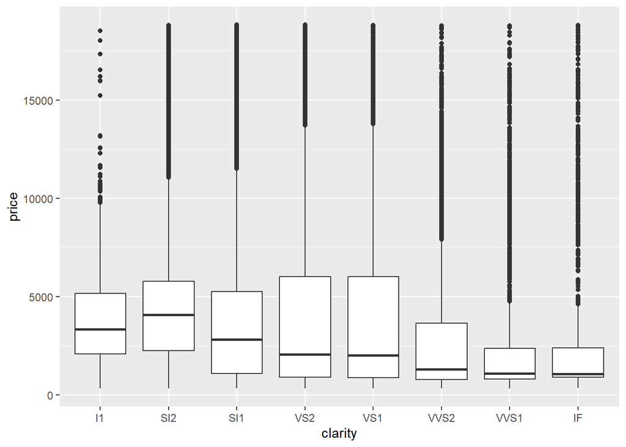

```r
#price ~ clarity
ggplot(diamonds, aes(x = clarity, y = price)) +
  geom_boxplot()
```

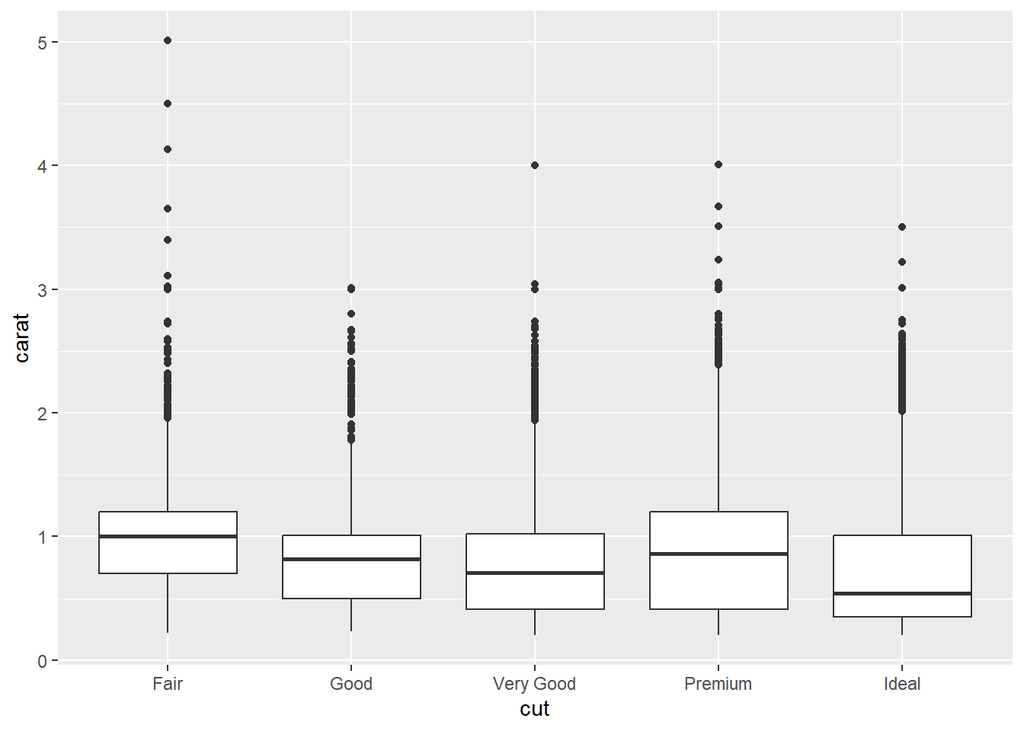

```r
#carat ~ cut
ggplot(diamonds, aes(x = cut, y = carat)) +
  geom_boxplot()
```

c) One problem with boxplots is that they were developed in an era of much smaller datasets and tend to display a prohibitively large number of “outlying values”. One approach to remedy this problem is the letter value plot. Install the lvplot package, and try using geom_lv() to display the distribution of price vs. cut. What do you learn? How do you interpret the plots?

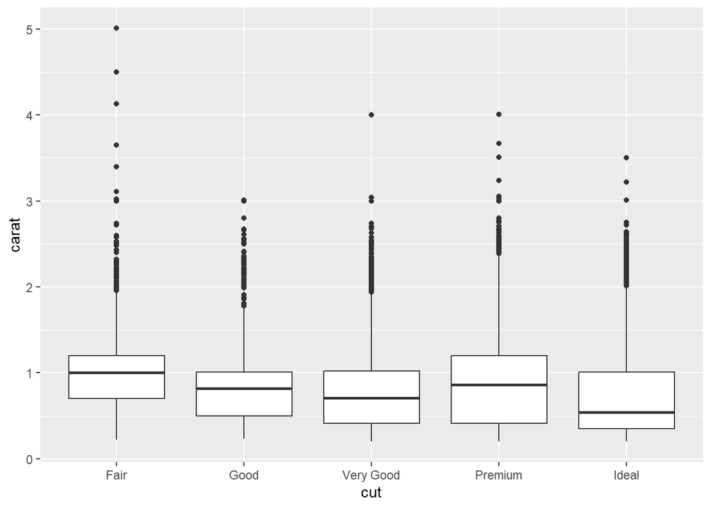

```r
ggplot(diamonds, aes(x = cut, y = carat)) +
  geom_boxplot()
```

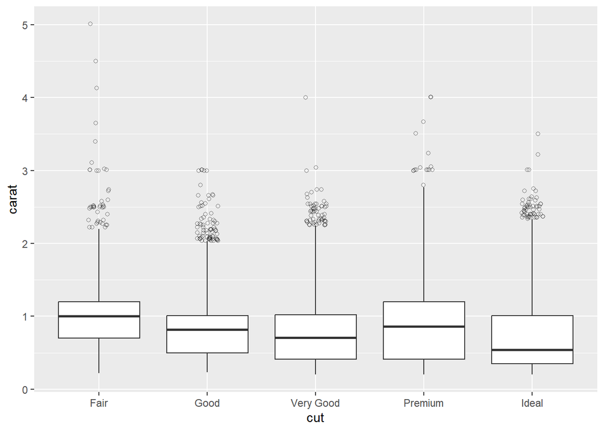

```r
diamonds |>
  group_by(cut) |>
  mutate(
    carat_out_lower = carat < quantile(carat,0.25) - IQR(carat) * 2.0,
    carat_out_upper = carat > quantile(carat,0.75) + IQR(carat) * 2.0,
    carat_out = if_else(carat_out_lower | carat_out_upper, carat, NA)
  ) |>
  ggplot(aes(x = cut, y = carat)) +
  geom_boxplot(outlier.shape = NA, coef = 2.0) +
  geom_jitter(aes(y = carat_out),
    height = 0,
    width = 0.1,
    shape = 1,
    size = 1.5,
    alpha = 0.5
  )
```

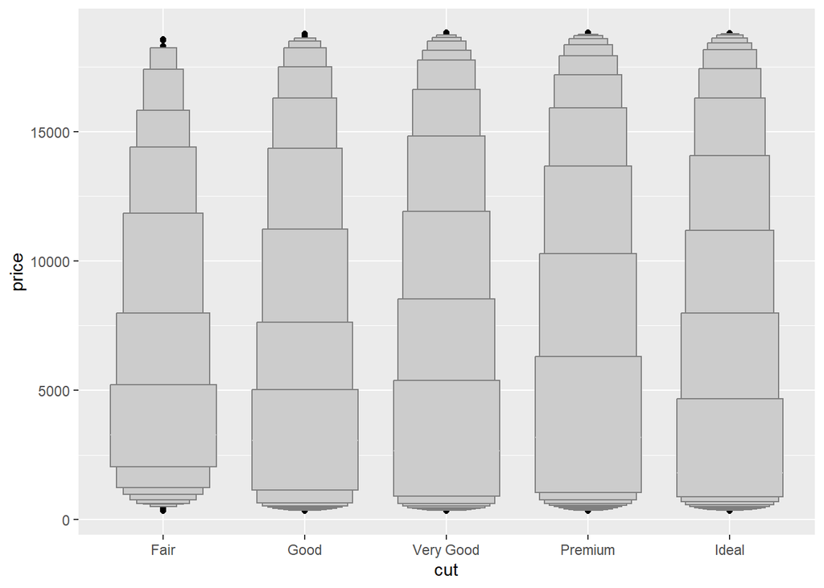

```r
ggplot(diamonds, aes(x = cut, y = price)) +
  geom_lv()
```

d) Create a visualization of diamond prices vs. a categorical variable from the diamonds dataset using geom_violin(), then a faceted geom_histogram(), then a colored geom_freqpoly(), and then a colored geom_density(). Compare and contrast the four plots. What are the pros and cons of each method of visualizing the distribution of a numerical variable based on the levels of a categorical variable?

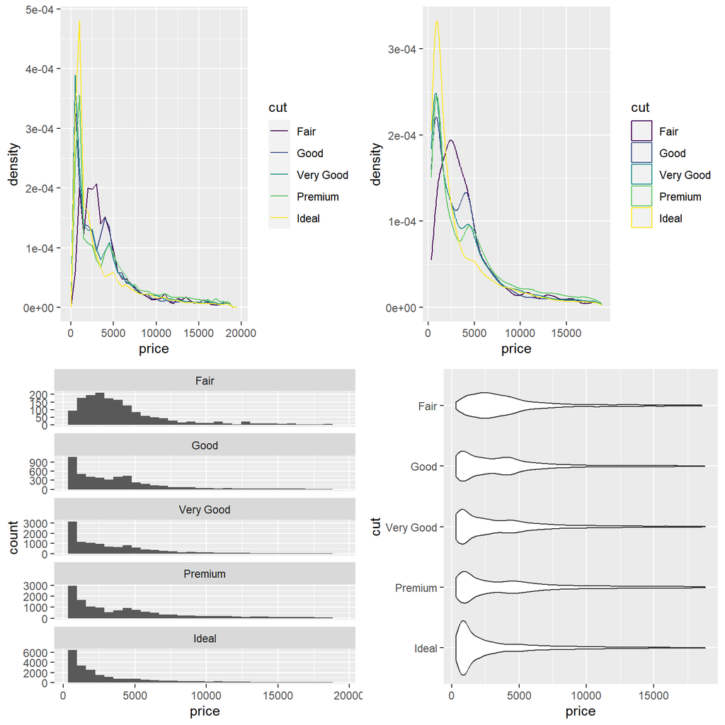

```r
#geom_freqpoly()
gg1 <- ggplot(diamonds, aes(x = price, y = after_stat(density), color = cut)) +
  geom_freqpoly(binwidth = 500)

#geom_histogram() with facet_wrap()
gg2 <- ggplot(diamonds, aes(x = price)) +
  geom_histogram() +
  facet_wrap(~cut, ncol = 1, scales = "free_y")

#geom_violin()
gg3 <- ggplot(diamonds, aes(x = price, y = cut)) +
  geom_violin() +
  scale_y_discrete(limits=rev)

#geom_density()
gg4 <- ggplot(diamonds, aes(x = price, color = cut)) +
  geom_density(bw = 500)

grid.arrange(gg1, gg4, gg2, gg3, ncol = 2)
```

e) If you have a small dataset, it’s sometimes useful to use geom_jitter() to avoid overplotting to more easily see the relationship between a continuous and categorical variable. The ggbeeswarm package provides a number of methods similar to geom_jitter(). List them and briefly describe what each one does.

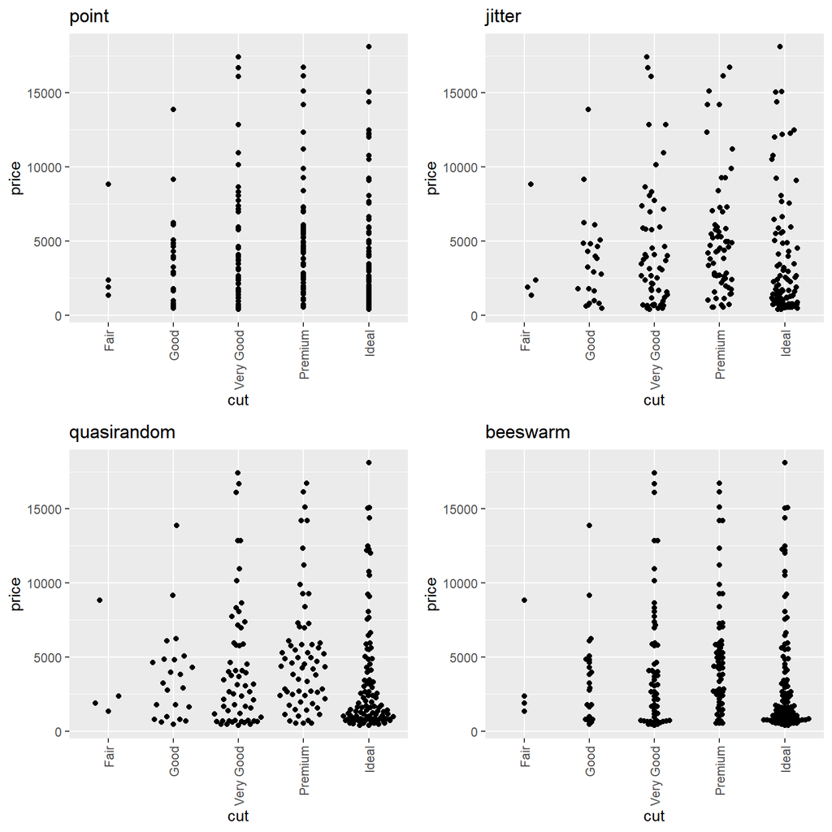

```r
set.seed(123)
diamonds2 <- diamonds |> slice_sample(n = 250)

#geom_point()
gg1 <- ggplot(diamonds2, aes(x = cut, y = price)) +
  geom_point() +
  scale_x_discrete(guide = guide_axis(angle = 90)) +
  labs(title = "point")

#geom_jitter()
gg2 <- ggplot(diamonds2, aes(x = cut, y = price)) +
  geom_jitter(height = 0, width = 0.2) +
  scale_x_discrete(guide = guide_axis(angle = 90)) +
  labs(title = "jitter")

#geom_quasirandom() with quasirandom()
gg3 <- ggplot(diamonds2, aes(x = cut, y = price)) +
  geom_quasirandom() +
  scale_x_discrete(guide = guide_axis(angle = 90)) +
  labs(title = "quasirandom")

#geom_beeswarm()
gg4 <- ggplot(diamonds2, aes(x = cut, y = price)) +
  geom_beeswarm() +
  scale_x_discrete(guide = guide_axis(angle = 90)) +
  labs(title = "beeswarm")

grid.arrange(gg1, gg2, gg3, gg4, ncol = 2)
```

## 3.2. TWO CATEGORICAL VARIABLES

a) How could you rescale the count dataset above to more clearly show the distribution of cut within color, or color within cut?

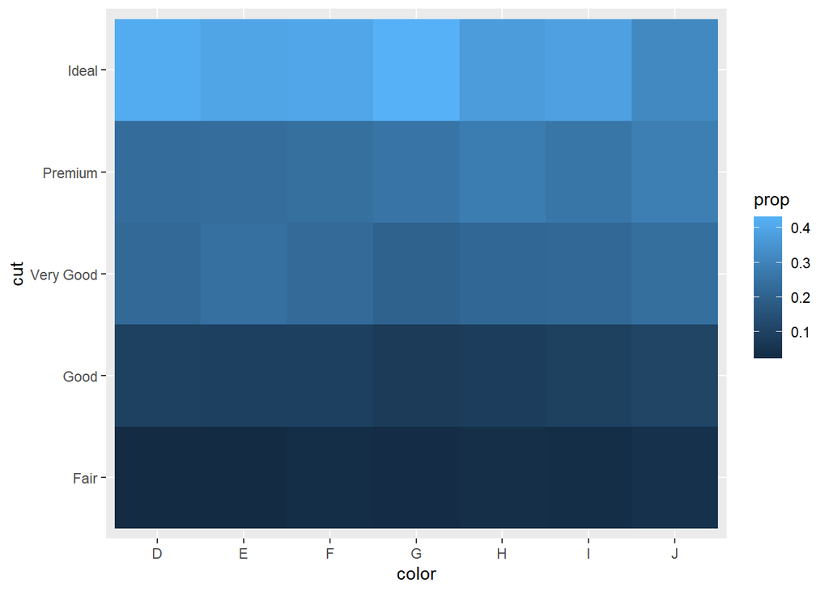

```r
#color within cut
diamonds |>
  count(color, cut) |>
  group_by(color) |>
  mutate(prop = n / sum(n)) |>
  ggplot(aes(x = color, y = cut, fill = prop)) +
  geom_tile()
```

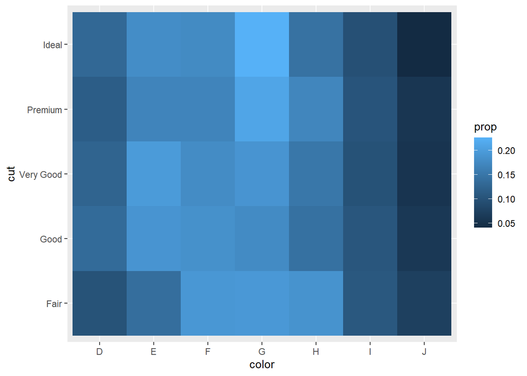

```r
#cut within color
diamonds |>
  count(color, cut) |>
  group_by(cut) |>
  mutate(prop = n / sum(n)) |>
  ggplot(aes(x = color, y = cut, fill = prop)) +
  geom_tile()
```

b) What different data insights do you get with a segmented bar chart if color is mapped to the x aesthetic and cut is mapped to the fill aesthetic? Calculate the counts that fall into each of the segments.

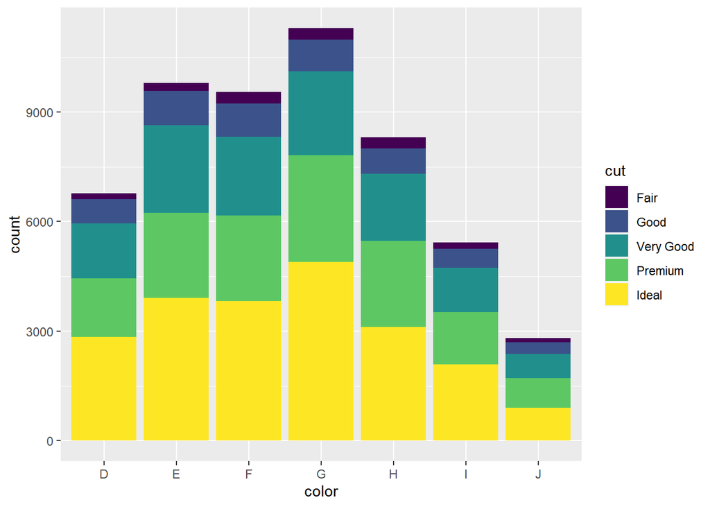

```r
#geom_bar()
ggplot(diamonds, aes(x = color, fill = cut)) +
  geom_bar()
```

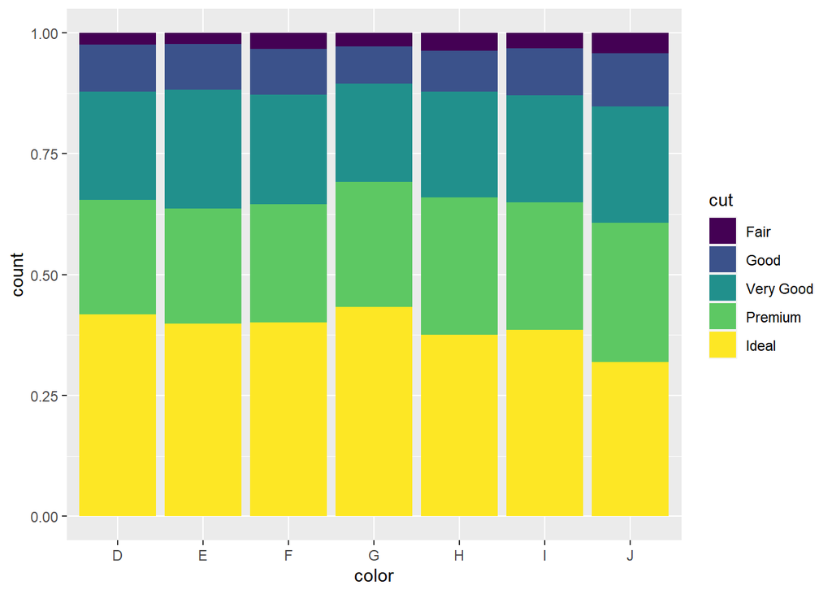

```r
#geom_bar()
ggplot(diamonds, aes(x = color, fill = cut)) +
  geom_bar(position="fill")
```